# Car Price Prediction

#### Insights

High ranged cars prefer rwd drivewheel with idi or mpfi fuelsystem.

#### List of significant variables after Visual analysis :

- Car Range
- Engine Type
- Fuel type
- Car Body
- Aspiration
- Cylinder Number
- Drivewheel
- Curbweight
- Car Length
- Car width
- Engine Size
- Boreratio
- Horse Power
- Wheel base
- Fuel Economy

```python
cars_lr = cars[['price', 'fueltype', 'aspiration','carbody', 'drivewheel','wheelbase',
                  'curbweight', 'enginetype', 'cylindernumber', 'enginesize', 'boreratio','horsepower',
                    'fueleconomy', 'carlength','carwidth', 'carsrange']]
cars_lr.head()
```

|  | price | fueltype | aspiration | carbody | drivewheel | wheelbase | curbweight | enginetype | cylindernumber | enginesize | boreratio | horsepower | fueleconomy | carlength | carwidth | carsrange |
| --- | --- | --- | --- | --- | --- | --- | --- | --- | --- | --- | --- | --- | --- | --- | --- | --- |
| 0 | 13495 | gas | std | convertible | rwd | 88.6 | 2548 | dohc | four | 130 | 3.47 | 111 | 23.70 | 168.8 | 64.1 | Medium |
| 1 | 16500 | gas | std | convertible | rwd | 88.6 | 2548 | dohc | four | 130 | 3.47 | 111 | 23.70 | 168.8 | 64.1 | Medium |
| 2 | 16500 | gas | std | hatchback | rwd | 94.5 | 2823 | ohcv | six | 152 | 2.68 | 154 | 22.15 | 171.2 | 65.5 | Medium |
| 3 | 13950 | gas | std | sedan | fwd | 99.8 | 2337 | ohc | four | 109 | 3.19 | 102 | 26.70 | 176.6 | 66.2 | Medium |
| 4 | 17450 | gas | std | sedan | 4wd | 99.4 | 2824 | ohc | five | 136 | 3.19 | 115 | 19.80 | 176.6 | 66.4 | Medium |

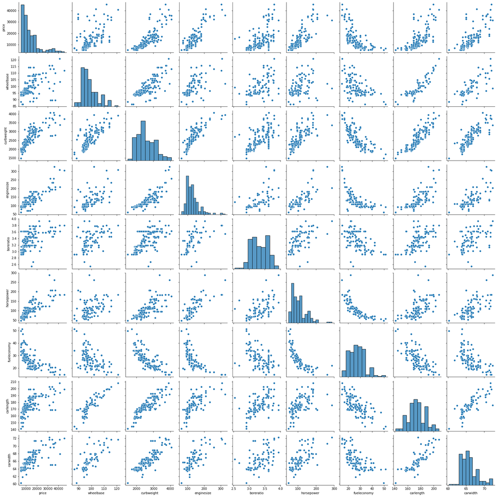

```python
sns.pairplot(cars_lr)
plt.show()
```

### Step 6 : Dummy Variables

```python
# Defining the map function
def dummies(x,df):
    temp = pd.get_dummies(df[x], drop_first = True)
    df = pd.concat([df, temp], axis = 1)
    df.drop([x], axis = 1, inplace = True)
    return df
# Applying the function to the cars_lr

cars_lr = dummies('fueltype',cars_lr)
cars_lr = dummies('aspiration',cars_lr)
cars_lr = dummies('carbody',cars_lr)
cars_lr = dummies('drivewheel',cars_lr)
cars_lr = dummies('enginetype',cars_lr)
cars_lr = dummies('cylindernumber',cars_lr)
cars_lr = dummies('carsrange',cars_lr)
```

```python
cars_lr.head()
```

|  | price | wheelbase | curbweight | enginesize | boreratio | horsepower | fueleconomy | carlength | carwidth | gas | ... | ohcv | rotor | five | four | six | three | twelve | two | Medium | Highend |
| --- | --- | --- | --- | --- | --- | --- | --- | --- | --- | --- | --- | --- | --- | --- | --- | --- | --- | --- | --- | --- | --- |
| 0 | 13495 | 88.6 | 2548 | 130 | 3.47 | 111 | 23.70 | 168.8 | 64.1 | 1 | ... | 0 | 0 | 0 | 1 | 0 | 0 | 0 | 0 | 1 | 0 |
| 1 | 16500 | 88.6 | 2548 | 130 | 3.47 | 111 | 23.70 | 168.8 | 64.1 | 1 | ... | 0 | 0 | 0 | 1 | 0 | 0 | 0 | 0 | 1 | 0 |
| 2 | 16500 | 94.5 | 2823 | 152 | 2.68 | 154 | 22.15 | 171.2 | 65.5 | 1 | ... | 1 | 0 | 0 | 0 | 1 | 0 | 0 | 0 | 1 | 0 |
| 3 | 13950 | 99.8 | 2337 | 109 | 3.19 | 102 | 26.70 | 176.6 | 66.2 | 1 | ... | 0 | 0 | 0 | 1 | 0 | 0 | 0 | 0 | 1 | 0 |
| 4 | 17450 | 99.4 | 2824 | 136 | 3.19 | 115 | 19.80 | 176.6 | 66.4 | 1 | ... | 0 | 0 | 1 | 0 | 0 | 0 | 0 | 0 | 1 | 0 |

5 rows × 31 columns

```python
cars_lr.shape
```

```
(205, 31)
```

#### Step 7 : Train-Test Split and feature scaling¶

```python
from sklearn.model_selection import train_test_split

np.random.seed(0)
df_train, df_test = train_test_split(cars_lr, train_size = 0.7, test_size = 0.3, random_state = 100)
```

```python
from sklearn.preprocessing import MinMaxScaler

scaler = MinMaxScaler()
num_vars = ['wheelbase', 'curbweight', 'enginesize', 'boreratio', 'horsepower','fueleconomy','carlength','carwidth','price']
df_train[num_vars] = scaler.fit_transform(df_train[num_vars])
```

```python
df_train.head()
```

|  | price | wheelbase | curbweight | enginesize | boreratio | horsepower | fueleconomy | carlength | carwidth | gas | ... | ohcv | rotor | five | four | six | three | twelve | two | Medium | Highend |
| --- | --- | --- | --- | --- | --- | --- | --- | --- | --- | --- | --- | --- | --- | --- | --- | --- | --- | --- | --- | --- | --- |
| 122 | 0.068818 | 0.244828 | 0.272692 | 0.139623 | 0.230159 | 0.083333 | 0.530864 | 0.426016 | 0.291667 | 1 | ... | 0 | 0 | 0 | 1 | 0 | 0 | 0 | 0 | 0 | 0 |
| 125 | 0.466890 | 0.272414 | 0.500388 | 0.339623 | 1.000000 | 0.395833 | 0.213992 | 0.452033 | 0.666667 | 1 | ... | 0 | 0 | 0 | 1 | 0 | 0 | 0 | 0 | 0 | 1 |
| 166 | 0.122110 | 0.272414 | 0.314973 | 0.139623 | 0.444444 | 0.266667 | 0.344307 | 0.448780 | 0.308333 | 1 | ... | 0 | 0 | 0 | 1 | 0 | 0 | 0 | 0 | 0 | 0 |
| 1 | 0.314446 | 0.068966 | 0.411171 | 0.260377 | 0.626984 | 0.262500 | 0.244170 | 0.450407 | 0.316667 | 1 | ... | 0 | 0 | 0 | 1 | 0 | 0 | 0 | 0 | 1 | 0 |
| 199 | 0.382131 | 0.610345 | 0.647401 | 0.260377 | 0.746032 | 0.475000 | 0.122085 | 0.775610 | 0.575000 | 1 | ... | 0 | 0 | 0 | 1 | 0 | 0 | 0 | 0 | 1 | 0 |

5 rows × 31 columns

```python
df_train.describe().T
```

|  | count | mean | std | min | 25% | 50% | 75% | max |
| --- | --- | --- | --- | --- | --- | --- | --- | --- |
| price | 143.0 | 0.219309 | 0.215682 | 0.0 | 0.067298 | 0.140343 | 0.313479 | 1.0 |
| wheelbase | 143.0 | 0.411141 | 0.205581 | 0.0 | 0.272414 | 0.341379 | 0.503448 | 1.0 |
| curbweight | 143.0 | 0.407878 | 0.211269 | 0.0 | 0.245539 | 0.355702 | 0.559542 | 1.0 |
| enginesize | 143.0 | 0.241351 | 0.154619 | 0.0 | 0.135849 | 0.184906 | 0.301887 | 1.0 |
| boreratio | 143.0 | 0.497946 | 0.207140 | 0.0 | 0.305556 | 0.500000 | 0.682540 | 1.0 |
| horsepower | 143.0 | 0.227302 | 0.165511 | 0.0 | 0.091667 | 0.191667 | 0.283333 | 1.0 |
| fueleconomy | 143.0 | 0.358265 | 0.185980 | 0.0 | 0.198903 | 0.344307 | 0.512346 | 1.0 |
| carlength | 143.0 | 0.525476 | 0.204848 | 0.0 | 0.399187 | 0.502439 | 0.669919 | 1.0 |
| carwidth | 143.0 | 0.461655 | 0.184517 | 0.0 | 0.304167 | 0.425000 | 0.550000 | 1.0 |
| gas | 143.0 | 0.909091 | 0.288490 | 0.0 | 1.000000 | 1.000000 | 1.000000 | 1.0 |
| turbo | 143.0 | 0.181818 | 0.387050 | 0.0 | 0.000000 | 0.000000 | 0.000000 | 1.0 |
| hardtop | 143.0 | 0.020979 | 0.143818 | 0.0 | 0.000000 | 0.000000 | 0.000000 | 1.0 |
| hatchback | 143.0 | 0.342657 | 0.476266 | 0.0 | 0.000000 | 0.000000 | 1.000000 | 1.0 |
| sedan | 143.0 | 0.475524 | 0.501156 | 0.0 | 0.000000 | 0.000000 | 1.000000 | 1.0 |
| wagon | 143.0 | 0.132867 | 0.340624 | 0.0 | 0.000000 | 0.000000 | 0.000000 | 1.0 |
| fwd | 143.0 | 0.594406 | 0.492733 | 0.0 | 0.000000 | 1.000000 | 1.000000 | 1.0 |
| rwd | 143.0 | 0.349650 | 0.478536 | 0.0 | 0.000000 | 0.000000 | 1.000000 | 1.0 |
| dohcv | 143.0 | 0.006993 | 0.083624 | 0.0 | 0.000000 | 0.000000 | 0.000000 | 1.0 |
| l | 143.0 | 0.062937 | 0.243703 | 0.0 | 0.000000 | 0.000000 | 0.000000 | 1.0 |
| ohc | 143.0 | 0.685315 | 0.466023 | 0.0 | 0.000000 | 1.000000 | 1.000000 | 1.0 |
| ohcf | 143.0 | 0.083916 | 0.278236 | 0.0 | 0.000000 | 0.000000 | 0.000000 | 1.0 |
| ohcv | 143.0 | 0.062937 | 0.243703 | 0.0 | 0.000000 | 0.000000 | 0.000000 | 1.0 |
| rotor | 143.0 | 0.027972 | 0.165472 | 0.0 | 0.000000 | 0.000000 | 0.000000 | 1.0 |
| five | 143.0 | 0.062937 | 0.243703 | 0.0 | 0.000000 | 0.000000 | 0.000000 | 1.0 |
| four | 143.0 | 0.741259 | 0.439483 | 0.0 | 0.000000 | 1.000000 | 1.000000 | 1.0 |
| six | 143.0 | 0.132867 | 0.340624 | 0.0 | 0.000000 | 0.000000 | 0.000000 | 1.0 |
| three | 143.0 | 0.006993 | 0.083624 | 0.0 | 0.000000 | 0.000000 | 0.000000 | 1.0 |
| twelve | 143.0 | 0.006993 | 0.083624 | 0.0 | 0.000000 | 0.000000 | 0.000000 | 1.0 |
| two | 143.0 | 0.027972 | 0.165472 | 0.0 | 0.000000 | 0.000000 | 0.000000 | 1.0 |
| Medium | 143.0 | 0.412587 | 0.494030 | 0.0 | 0.000000 | 0.000000 | 1.000000 | 1.0 |
| Highend | 143.0 | 0.118881 | 0.324786 | 0.0 | 0.000000 | 0.000000 | 0.000000 | 1.0 |

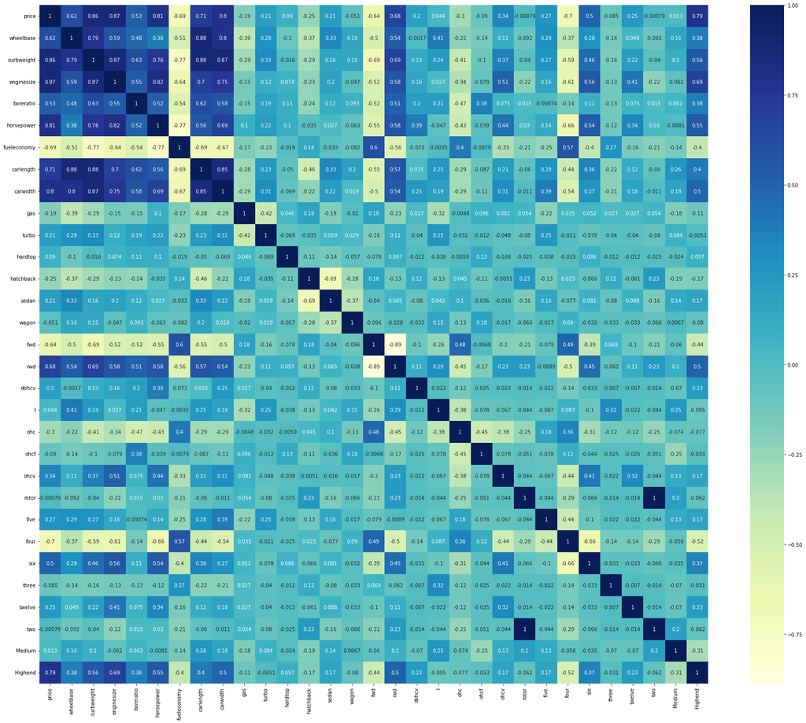

```python
#Correlation using heatmap
plt.figure(figsize = (30, 25))
sns.heatmap(df_train.corr(), annot = True, cmap="YlGnBu")
plt.show()
```

Highly correlated variables to price are - curbweight, enginesize, horsepower,carwidth and highend.

```python
#Dividing data into X and y variables
y_train = df_train.pop('price')
X_train = df_train
```

### Step 8 : Model Building

```python
#RFE
from sklearn.feature_selection import RFE
from sklearn.linear_model import LinearRegression
import statsmodels.api as sm
from statsmodels.stats.outliers_influence import variance_inflation_factor
```

```python
lm = LinearRegression()
lm.fit(X_train,y_train)
rfe = RFE(lm)
rfe = rfe.fit(X_train, y_train)
```

```python
list(zip(X_train.columns,rfe.support_,rfe.ranking_))
```

```
[('wheelbase', True, 1),
 ('curbweight', True, 1),
 ('enginesize', False, 8),
 ('boreratio', False, 5),
 ('horsepower', True, 1),
 ('fueleconomy', True, 1),
 ('carlength', False, 6),
 ('carwidth', True, 1),
 ('gas', False, 12),
 ('turbo', False, 13),
 ('hardtop', True, 1),
 ('hatchback', True, 1),
 ('sedan', True, 1),
 ('wagon', True, 1),
 ('fwd', False, 11),
 ('rwd', False, 10),
 ('dohcv', True, 1),
 ('l', False, 14),
 ('ohc', False, 2),
 ('ohcf', False, 3),
 ('ohcv', False, 4),
 ('rotor', False, 16),
 ('five', True, 1),
 ('four', True, 1),
 ('six', True, 1),
 ('three', False, 9),
 ('twelve', True, 1),
 ('two', False, 15),
 ('Medium', False, 7),
 ('Highend', True, 1)]
```

```python
X_train.columns[rfe.support_]
```

```
Index(['wheelbase', 'curbweight', 'horsepower', 'fueleconomy', 'carwidth',
       'hardtop', 'hatchback', 'sedan', 'wagon', 'dohcv', 'five', 'four',
       'six', 'twelve', 'Highend'],
      dtype='object')
```

Building model using statsmodel, for the detailed statistics

```python
X_train_rfe = X_train[X_train.columns[rfe.support_]]
X_train_rfe.head()
```

|  | wheelbase | curbweight | horsepower | fueleconomy | carwidth | hardtop | hatchback | sedan | wagon | dohcv | five | four | six | twelve | Highend |
| --- | --- | --- | --- | --- | --- | --- | --- | --- | --- | --- | --- | --- | --- | --- | --- |
| 122 | 0.244828 | 0.272692 | 0.083333 | 0.530864 | 0.291667 | 0 | 0 | 1 | 0 | 0 | 0 | 1 | 0 | 0 | 0 |
| 125 | 0.272414 | 0.500388 | 0.395833 | 0.213992 | 0.666667 | 0 | 1 | 0 | 0 | 0 | 0 | 1 | 0 | 0 | 1 |
| 166 | 0.272414 | 0.314973 | 0.266667 | 0.344307 | 0.308333 | 0 | 1 | 0 | 0 | 0 | 0 | 1 | 0 | 0 | 0 |
| 1 | 0.068966 | 0.411171 | 0.262500 | 0.244170 | 0.316667 | 0 | 0 | 0 | 0 | 0 | 0 | 1 | 0 | 0 | 0 |
| 199 | 0.610345 | 0.647401 | 0.475000 | 0.122085 | 0.575000 | 0 | 0 | 0 | 1 | 0 | 0 | 1 | 0 | 0 | 0 |

```python
def build_model(X,y):
    X = sm.add_constant(X) #Adding the constant
    lm = sm.OLS(y,X).fit() # fitting the model
    print(lm.summary()) # model summary
    return X

def checkVIF(X):
    vif = pd.DataFrame()
    vif['Features'] = X.columns
    vif['VIF'] = [variance_inflation_factor(X.values, i) for i in range(X.shape[1])]
    vif['VIF'] = round(vif['VIF'], 2)
    vif = vif.sort_values(by = "VIF", ascending = False)
    return(vif)
```

## MODEL 1

```python
X_train_new = build_model(X_train_rfe,y_train)
```

```
                            OLS Regression Results
==============================================================================
Dep. Variable:                  price   R-squared:                       0.936
Model:                            OLS   Adj. R-squared:                  0.929
Method:                 Least Squares   F-statistic:                     124.4
Date:                Mon, 20 Jun 2022   Prob (F-statistic):           3.16e-68
Time:                        20:16:01   Log-Likelihood:                 213.80
No. Observations:                 143   AIC:                            -395.6
Df Residuals:                     127   BIC:                            -348.2
Df Model:                          15
Covariance Type:            nonrobust
===============================================================================
                  coef    std err          t      P>|t|      [0.025      0.975]
-------------------------------------------------------------------------------
const           0.0108      0.050      0.214      0.831      -0.089       0.110
wheelbase       0.0814      0.063      1.298      0.197      -0.043       0.205
curbweight      0.2017      0.081      2.482      0.014       0.041       0.362
horsepower      0.4801      0.098      4.923      0.000       0.287       0.673
fueleconomy     0.1300      0.054      2.418      0.017       0.024       0.236
carwidth        0.2140      0.074      2.903      0.004       0.068       0.360
hardtop        -0.0611      0.048     -1.278      0.204      -0.156       0.034
hatchback      -0.1379      0.035     -3.977      0.000      -0.206      -0.069
sedan          -0.1119      0.036     -3.133      0.002      -0.183      -0.041
wagon          -0.1350      0.036     -3.708      0.000      -0.207      -0.063
dohcv          -0.2880      0.086     -3.360      0.001      -0.458      -0.118
five           -0.0416      0.031     -1.346      0.181      -0.103       0.020
four           -0.0802      0.025     -3.249      0.001      -0.129      -0.031
six            -0.0425      0.030     -1.400      0.164      -0.103       0.018
twelve         -0.1348      0.075     -1.790      0.076      -0.284       0.014
Highend         0.2416      0.020     12.095      0.000       0.202       0.281
==============================================================================
Omnibus:                       54.936   Durbin-Watson:                   2.013
Prob(Omnibus):                  0.000   Jarque-Bera (JB):              231.186
Skew:                           1.331   Prob(JB):                     6.29e-51
Kurtosis:                       8.632   Cond. No.                         46.8
==============================================================================

Notes:
[1] Standard Errors assume that the covariance matrix of the errors is correctly specified.
```

p-vale of twelve seems to be higher than the significance value of 0.05, hence dropping it as it is insignificant in presence of other variables.

```python
X_train_new = X_train_rfe.drop(["twelve"], axis = 1)
```

## MODEL 2

```python
X_train_new = build_model(X_train_new,y_train)
```

```
                            OLS Regression Results
==============================================================================
Dep. Variable:                  price   R-squared:                       0.935
Model:                            OLS   Adj. R-squared:                  0.928
Method:                 Least Squares   F-statistic:                     130.8
Date:                Mon, 20 Jun 2022   Prob (F-statistic):           1.30e-68
Time:                        20:18:30   Log-Likelihood:                 212.01
No. Observations:                 143   AIC:                            -394.0
Df Residuals:                     128   BIC:                            -349.6
Df Model:                          14
Covariance Type:            nonrobust
===============================================================================
                  coef    std err          t      P>|t|      [0.025      0.975]
-------------------------------------------------------------------------------
const           0.0290      0.050      0.585      0.559      -0.069       0.127
wheelbase       0.0828      0.063      1.310      0.192      -0.042       0.208
curbweight      0.1990      0.082      2.428      0.017       0.037       0.361
horsepower      0.4028      0.088      4.568      0.000       0.228       0.577
fueleconomy     0.1006      0.052      1.949      0.054      -0.002       0.203
carwidth        0.2227      0.074      3.003      0.003       0.076       0.369
hardtop        -0.0603      0.048     -1.251      0.213      -0.156       0.035
hatchback      -0.1428      0.035     -4.099      0.000      -0.212      -0.074
sedan          -0.1205      0.036     -3.377      0.001      -0.191      -0.050
wagon          -0.1441      0.036     -3.965      0.000      -0.216      -0.072
dohcv          -0.2231      0.078     -2.848      0.005      -0.378      -0.068
five           -0.0269      0.030     -0.894      0.373      -0.086       0.033
four           -0.0697      0.024     -2.882      0.005      -0.118      -0.022
six            -0.0168      0.027     -0.621      0.536      -0.070       0.037
Highend         0.2391      0.020     11.896      0.000       0.199       0.279
==============================================================================
Omnibus:                       57.668   Durbin-Watson:                   2.055
Prob(Omnibus):                  0.000   Jarque-Bera (JB):              257.568
Skew:                           1.384   Prob(JB):                     1.17e-56
Kurtosis:                       8.964   Cond. No.                         42.2
==============================================================================

Notes:
[1] Standard Errors assume that the covariance matrix of the errors is correctly specified.
```

```python
X_train_new = X_train_new.drop(["fueleconomy"], axis = 1)
```

## MODEL 3

```python
X_train_new = build_model(X_train_new,y_train)
```

```
                            OLS Regression Results
==============================================================================
Dep. Variable:                  price   R-squared:                       0.933
Model:                            OLS   Adj. R-squared:                  0.926
Method:                 Least Squares   F-statistic:                     137.6
Date:                Mon, 20 Jun 2022   Prob (F-statistic):           6.97e-69
Time:                        20:19:17   Log-Likelihood:                 209.92
No. Observations:                 143   AIC:                            -391.8
Df Residuals:                     129   BIC:                            -350.4
Df Model:                          13
Covariance Type:            nonrobust
==============================================================================
                 coef    std err          t      P>|t|      [0.025      0.975]
------------------------------------------------------------------------------
const          0.0765      0.044      1.751      0.082      -0.010       0.163
wheelbase      0.0636      0.063      1.007      0.316      -0.061       0.188
curbweight     0.1878      0.083      2.273      0.025       0.024       0.351
horsepower     0.3125      0.076      4.121      0.000       0.162       0.463
carwidth       0.2303      0.075      3.076      0.003       0.082       0.378
hardtop       -0.0452      0.048     -0.939      0.349      -0.140       0.050
hatchback     -0.1306      0.035     -3.770      0.000      -0.199      -0.062
sedan         -0.1074      0.035     -3.032      0.003      -0.178      -0.037
wagon         -0.1357      0.036     -3.719      0.000      -0.208      -0.063
dohcv         -0.1710      0.074     -2.298      0.023      -0.318      -0.024
five          -0.0288      0.030     -0.949      0.344      -0.089       0.031
four          -0.0642      0.024     -2.644      0.009      -0.112      -0.016
six           -0.0080      0.027     -0.297      0.767      -0.061       0.045
Highend        0.2457      0.020     12.277      0.000       0.206       0.285
==============================================================================
Omnibus:                       55.631   Durbin-Watson:                   2.071
Prob(Omnibus):                  0.000   Jarque-Bera (JB):              231.246
Skew:                           1.356   Prob(JB):                     6.10e-51
Kurtosis:                       8.608   Cond. No.                         38.7
==============================================================================

Notes:
[1] Standard Errors assume that the covariance matrix of the errors is correctly specified.
```

```python
#Calculating the Variance Inflation Factor
checkVIF(X_train_new)
```

|  | Features | VIF |
| --- | --- | --- |
| 0 | const | 79.21 |
| 7 | sedan | 13.00 |
| 2 | curbweight | 12.56 |
| 6 | hatchback | 11.22 |
| 4 | carwidth | 7.87 |
| 1 | wheelbase | 6.94 |
| 3 | horsepower | 6.49 |
| 8 | wagon | 6.36 |
| 11 | four | 4.69 |
| 12 | six | 3.46 |
| 10 | five | 2.26 |
| 5 | hardtop | 1.97 |
| 13 | Highend | 1.74 |
| 9 | dohcv | 1.60 |

#### dropping curbweight because of high VIF value. (shows that curbweight has high multicollinearity.)

```python
X_train_new = X_train_new.drop(["curbweight"], axis = 1)
```

### MODEL 4

```python
X_train_new = build_model(X_train_new,y_train)
```

```
                            OLS Regression Results
==============================================================================
Dep. Variable:                  price   R-squared:                       0.930
Model:                            OLS   Adj. R-squared:                  0.924
Method:                 Least Squares   F-statistic:                     144.0
Date:                Mon, 20 Jun 2022   Prob (F-statistic):           7.03e-69
Time:                        20:20:48   Log-Likelihood:                 207.12
No. Observations:                 143   AIC:                            -388.2
Df Residuals:                     130   BIC:                            -349.7
Df Model:                          12
Covariance Type:            nonrobust
==============================================================================
                 coef    std err          t      P>|t|      [0.025      0.975]
------------------------------------------------------------------------------
const          0.1005      0.043      2.334      0.021       0.015       0.186
wheelbase      0.1430      0.053      2.678      0.008       0.037       0.249
horsepower     0.4157      0.062      6.733      0.000       0.294       0.538
carwidth       0.2810      0.073      3.870      0.000       0.137       0.425
hardtop       -0.0752      0.047     -1.602      0.112      -0.168       0.018
hatchback     -0.1602      0.033     -4.915      0.000      -0.225      -0.096
sedan         -0.1368      0.034     -4.084      0.000      -0.203      -0.071
wagon         -0.1521      0.036     -4.188      0.000      -0.224      -0.080
dohcv         -0.2222      0.072     -3.084      0.002      -0.365      -0.080
five          -0.0299      0.031     -0.969      0.334      -0.091       0.031
four          -0.0652      0.025     -2.646      0.009      -0.114      -0.016
six           -0.0054      0.027     -0.198      0.843      -0.059       0.049
Highend        0.2532      0.020     12.625      0.000       0.214       0.293
==============================================================================
Omnibus:                       50.599   Durbin-Watson:                   2.173
Prob(Omnibus):                  0.000   Jarque-Bera (JB):              180.478
Skew:                           1.276   Prob(JB):                     6.45e-40
Kurtosis:                       7.876   Cond. No.                         30.8
==============================================================================

Notes:
[1] Standard Errors assume that the covariance matrix of the errors is correctly specified.
```

```python
checkVIF(X_train_new)
```

|  | Features | VIF |
| --- | --- | --- |
| 0 | const | 74.57 |
| 6 | sedan | 11.26 |
| 5 | hatchback | 9.63 |
| 3 | carwidth | 7.17 |
| 7 | wagon | 6.11 |
| 1 | wheelbase | 4.81 |
| 10 | four | 4.69 |
| 2 | horsepower | 4.17 |
| 11 | six | 3.45 |
| 9 | five | 2.26 |
| 4 | hardtop | 1.82 |
| 12 | Highend | 1.69 |
| 8 | dohcv | 1.45 |

```python
X_train_new = X_train_new.drop(["sedan"], axis = 1)
```

### MODEL 5

```python
X_train_new = build_model(X_train_new,y_train)
```

```
                            OLS Regression Results
==============================================================================
Dep. Variable:                  price   R-squared:                       0.921
Model:                            OLS   Adj. R-squared:                  0.914
Method:                 Least Squares   F-statistic:                     138.9
Date:                Mon, 20 Jun 2022   Prob (F-statistic):           1.42e-66
Time:                        20:21:27   Log-Likelihood:                 198.49
No. Observations:                 143   AIC:                            -373.0
Df Residuals:                     131   BIC:                            -337.4
Df Model:                          11
Covariance Type:            nonrobust
==============================================================================
                 coef    std err          t      P>|t|      [0.025      0.975]
------------------------------------------------------------------------------
const         -0.0185      0.034     -0.551      0.583      -0.085       0.048
wheelbase      0.0721      0.053      1.350      0.179      -0.034       0.178
horsepower     0.4240      0.065      6.494      0.000       0.295       0.553
carwidth       0.3352      0.076      4.437      0.000       0.186       0.485
hardtop        0.0452      0.039      1.170      0.244      -0.031       0.122
hatchback     -0.0368      0.013     -2.846      0.005      -0.062      -0.011
wagon         -0.0185      0.017     -1.107      0.270      -0.052       0.015
dohcv         -0.2664      0.075     -3.535      0.001      -0.416      -0.117
five          -0.0453      0.032     -1.399      0.164      -0.109       0.019
four          -0.0711      0.026     -2.729      0.007      -0.123      -0.020
six           -0.0171      0.029     -0.596      0.552      -0.074       0.040
Highend        0.2593      0.021     12.251      0.000       0.217       0.301
==============================================================================
Omnibus:                       41.290   Durbin-Watson:                   2.035
Prob(Omnibus):                  0.000   Jarque-Bera (JB):              103.797
Skew:                           1.158   Prob(JB):                     2.89e-23
Kurtosis:                       6.473   Cond. No.                         27.8
==============================================================================

Notes:
[1] Standard Errors assume that the covariance matrix of the errors is correctly specified.
```

```python
checkVIF(X_train_new)
```

|  | Features | VIF |
| --- | --- | --- |
| 0 | const | 40.43 |
| 3 | carwidth | 6.93 |
| 9 | four | 4.67 |
| 1 | wheelbase | 4.30 |
| 2 | horsepower | 4.17 |
| 10 | six | 3.42 |
| 8 | five | 2.22 |
| 11 | Highend | 1.69 |
| 7 | dohcv | 1.42 |
| 5 | hatchback | 1.35 |
| 6 | wagon | 1.15 |
| 4 | hardtop | 1.10 |

dropping wagon because of high p-value.

```python
X_train_new = X_train_new.drop(["wagon"], axis = 1)
```

### MODEL 6

```python
X_train_new = build_model(X_train_new,y_train)
```

```
                            OLS Regression Results
==============================================================================
Dep. Variable:                  price   R-squared:                       0.920
Model:                            OLS   Adj. R-squared:                  0.914
Method:                 Least Squares   F-statistic:                     152.4
Date:                Mon, 20 Jun 2022   Prob (F-statistic):           2.05e-67
Time:                        20:22:22   Log-Likelihood:                 197.82
No. Observations:                 143   AIC:                            -373.6
Df Residuals:                     132   BIC:                            -341.0
Df Model:                          10
Covariance Type:            nonrobust
==============================================================================
                 coef    std err          t      P>|t|      [0.025      0.975]
------------------------------------------------------------------------------
const         -0.0219      0.033     -0.655      0.514      -0.088       0.044
wheelbase      0.0620      0.053      1.176      0.242      -0.042       0.166
horsepower     0.4200      0.065      6.436      0.000       0.291       0.549
carwidth       0.3452      0.075      4.600      0.000       0.197       0.494
hardtop        0.0481      0.039      1.245      0.215      -0.028       0.124
hatchback     -0.0333      0.013     -2.653      0.009      -0.058      -0.008
dohcv         -0.2711      0.075     -3.600      0.000      -0.420      -0.122
five          -0.0449      0.032     -1.386      0.168      -0.109       0.019
four          -0.0715      0.026     -2.741      0.007      -0.123      -0.020
six           -0.0163      0.029     -0.567      0.572      -0.073       0.041
Highend        0.2620      0.021     12.449      0.000       0.220       0.304
==============================================================================
Omnibus:                       43.687   Durbin-Watson:                   2.039
Prob(Omnibus):                  0.000   Jarque-Bera (JB):              113.317
Skew:                           1.215   Prob(JB):                     2.47e-25
Kurtosis:                       6.621   Cond. No.                         27.5
==============================================================================

Notes:
[1] Standard Errors assume that the covariance matrix of the errors is correctly specified.
```

```python
checkVIF(X_train_new)
```

|  | Features | VIF |
| --- | --- | --- |
| 0 | const | 40.08 |
| 3 | carwidth | 6.83 |
| 8 | four | 4.67 |
| 1 | wheelbase | 4.17 |
| 2 | horsepower | 4.15 |
| 9 | six | 3.41 |
| 7 | five | 2.22 |
| 10 | Highend | 1.66 |
| 6 | dohcv | 1.41 |
| 5 | hatchback | 1.27 |
| 4 | hardtop | 1.10 |

### MODEL 7

```python
#Dropping dohcv to see the changes in model statistics
X_train_new = X_train_new.drop(["dohcv"], axis = 1)
X_train_new = build_model(X_train_new,y_train)
checkVIF(X_train_new)
```

```
                            OLS Regression Results
==============================================================================
Dep. Variable:                  price   R-squared:                       0.912
Model:                            OLS   Adj. R-squared:                  0.907
Method:                 Least Squares   F-statistic:                     154.1
Date:                Mon, 20 Jun 2022   Prob (F-statistic):           7.49e-66
Time:                        20:22:49   Log-Likelihood:                 191.12
No. Observations:                 143   AIC:                            -362.2
Df Residuals:                     133   BIC:                            -332.6
Df Model:                           9
Covariance Type:            nonrobust
==============================================================================
                 coef    std err          t      P>|t|      [0.025      0.975]
------------------------------------------------------------------------------
const         -0.0159      0.035     -0.455      0.650      -0.085       0.053
wheelbase      0.0871      0.055      1.597      0.113      -0.021       0.195
horsepower     0.3559      0.066      5.431      0.000       0.226       0.486
carwidth       0.3216      0.078      4.120      0.000       0.167       0.476
hardtop        0.0561      0.040      1.394      0.166      -0.024       0.136
hatchback     -0.0359      0.013     -2.744      0.007      -0.062      -0.010
five          -0.0269      0.033     -0.803      0.423      -0.093       0.039
four          -0.0659      0.027     -2.425      0.017      -0.120      -0.012
six            0.0096      0.029      0.329      0.743      -0.048       0.067
Highend        0.2555      0.022     11.672      0.000       0.212       0.299
==============================================================================
Omnibus:                       37.727   Durbin-Watson:                   2.000
Prob(Omnibus):                  0.000   Jarque-Bera (JB):              103.259
Skew:                           1.015   Prob(JB):                     3.78e-23
Kurtosis:                       6.634   Cond. No.                         27.4
==============================================================================

Notes:
[1] Standard Errors assume that the covariance matrix of the errors is correctly specified.
```

|  | Features | VIF |
| --- | --- | --- |
| 0 | const | 39.98 |
| 3 | carwidth | 6.78 |
| 7 | four | 4.66 |
| 1 | wheelbase | 4.10 |
| 2 | horsepower | 3.84 |
| 8 | six | 3.20 |
| 6 | five | 2.17 |
| 9 | Highend | 1.65 |
| 5 | hatchback | 1.27 |
| 4 | hardtop | 1.09 |

### Step 9 : Residual Analysis of Model

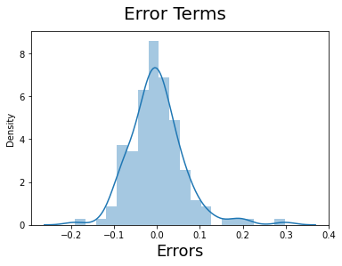

```python
lm = sm.OLS(y_train,X_train_new).fit()
y_train_price = lm.predict(X_train_new)

# Plot the histogram of the error terms
fig = plt.figure()
sns.distplot((y_train - y_train_price), bins = 20)
fig.suptitle('Error Terms', fontsize = 20)                  # Plot heading
plt.xlabel('Errors', fontsize = 18)
```

**Error terms seem to be approximately normally distributed, so the assumption on the linear modeling seems to be fulfilled.

### Step 10 : Prediction and Evaluation

```python
#Scaling the test set
num_vars = ['wheelbase', 'curbweight', 'enginesize', 'boreratio', 'horsepower','fueleconomy','carlength','carwidth','price']
df_test[num_vars] = scaler.fit_transform(df_test[num_vars])
```

```python
#Dividing into X and y
y_test = df_test.pop('price')
X_test = df_test


# Now let's use our model to make predictions.
X_train_new = X_train_new.drop('const',axis=1)
# Creating X_test_new dataframe by dropping variables from X_test
X_test_new = X_test[X_train_new.columns]

# Adding a constant variable
X_test_new = sm.add_constant(X_test_new)


# Making predictions
y_pred = lm.predict(X_test_new)
```

Evaluation of test via comparison of y_pred and y_test

```python
from sklearn.metrics import r2_score
r2_score(y_test, y_pred)
```

```
0.8816925583799404
```

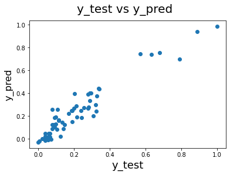

```python
#EVALUATION OF THE MODEL
# Plotting y_test and y_pred to understand the spread.
fig = plt.figure()
plt.scatter(y_test,y_pred)
fig.suptitle('y_test vs y_pred', fontsize=20)              # Plot heading
plt.xlabel('y_test', fontsize=18)                          # X-label
plt.ylabel('y_pred', fontsize=16)
```

**Evaluation of the model using Statistics

```python
print(lm.summary())
```

```
                            OLS Regression Results
==============================================================================
Dep. Variable:                  price   R-squared:                       0.912
Model:                            OLS   Adj. R-squared:                  0.907
Method:                 Least Squares   F-statistic:                     154.1
Date:                Mon, 20 Jun 2022   Prob (F-statistic):           7.49e-66
Time:                        20:25:22   Log-Likelihood:                 191.12
No. Observations:                 143   AIC:                            -362.2
Df Residuals:                     133   BIC:                            -332.6
Df Model:                           9
Covariance Type:            nonrobust
==============================================================================
                 coef    std err          t      P>|t|      [0.025      0.975]
------------------------------------------------------------------------------
const         -0.0159      0.035     -0.455      0.650      -0.085       0.053
wheelbase      0.0871      0.055      1.597      0.113      -0.021       0.195
horsepower     0.3559      0.066      5.431      0.000       0.226       0.486
carwidth       0.3216      0.078      4.120      0.000       0.167       0.476
hardtop        0.0561      0.040      1.394      0.166      -0.024       0.136
hatchback     -0.0359      0.013     -2.744      0.007      -0.062      -0.010
five          -0.0269      0.033     -0.803      0.423      -0.093       0.039
four          -0.0659      0.027     -2.425      0.017      -0.120      -0.012
six            0.0096      0.029      0.329      0.743      -0.048       0.067
Highend        0.2555      0.022     11.672      0.000       0.212       0.299
==============================================================================
Omnibus:                       37.727   Durbin-Watson:                   2.000
Prob(Omnibus):                  0.000   Jarque-Bera (JB):              103.259
Skew:                           1.015   Prob(JB):                     3.78e-23
Kurtosis:                       6.634   Cond. No.                         27.4
==============================================================================

Notes:
[1] Standard Errors assume that the covariance matrix of the errors is correctly specified.
```